# 2025 537 Survival Data Analysis: PH Model Examples

Ting Ye Departments of Biostatistics University of Washington

2025-01-28

## Mortality and FLCs

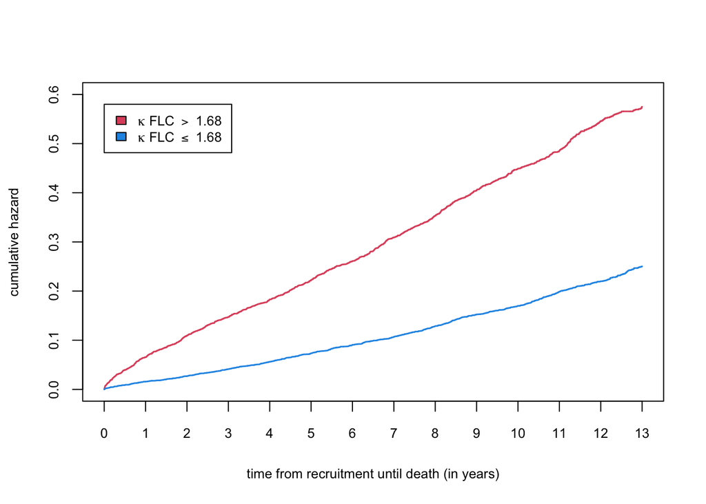

```r
library(survival)
library(timereg)
data(flchain)
flchain$abnormalvalue<-0;
flchain$abnormalvalue[which(flchain$lambda<0.57)]<-1;
flchain$abnormalvalue[which(flchain$lambda>2.63)]<-1;
flchain$abnormalvalue[which(flchain$kappa<0.33)]<-1;
flchain$abnormalvalue[which(flchain$kappa>1.94)]<-1;
flchain$sumflc<-flchain$lambda+flchain$kappa;
fit_1<-coxph(Surv(futime,as.numeric(death==1))~1,subset=(lambda>=1.68),data=flchain)
fit_0<-coxph(Surv(futime,as.numeric(death==1))~1,subset=(lambda<1.68),data=flchain)
b_1<-basehaz(fit_1); b_0<-basehaz(fit_0);
Lambda_0<-stepfun(b_0$time/365.25,c(0,b_0$hazard));
Lambda_1<-stepfun(b_1$time/365.25,c(0,b_1$hazard));
curve(Lambda_1,0,13,col=2,n=10000,ylim=c(0,0.6),xaxt='n',
ylab="cumulative hazard",
xlab="time from recruitment until death (in years)",cex.axis=0.8,cex.lab=0.8,lwd=1.5)
axis(1,at=seq(0,13,by=1),cex.axis=0.8)
curve(Lambda_0,add=TRUE,n=10000,col=4,lwd=1.5)
legend(0,0.58,legend=c(expression(paste(kappa," FLC ")>" 1.68 "),expression(paste(kappa," FLC ")<=" 1.68 ")),fill=c(2,4),cex=0.8)
```

We examine proportionality, and not too far off:

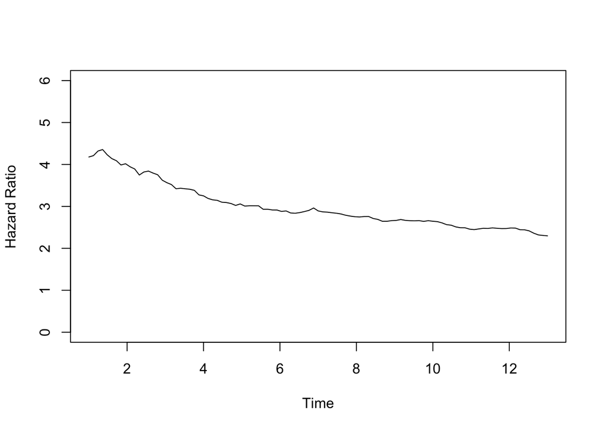

```r
ratio<-function(u) Lambda_1(u)/Lambda_0(u);
curve(ratio,1,13,ylim=c(0,6),ylab="Hazard Ratio",xlab="Time")
```

## Some examples

Recall the hazard in a population defined by a covariate value $Z$ is
$$h(t|Z)
= \frac{f(t|Z)}{S(t|Z)}.$$

In the first example we take a Weibull with parameters shape $a=4$ and scale $b=20$ in one group and in the second, we multiply the hazard by 2, to give a PH model.

Note: Weibull model is parameterized as
$$f(t) = \frac{a}{b} \left(
\frac{t}{b}\right)^{a-1}\exp\left[
-\left(
\frac{t}{b}\right)^a
\right],$$
for $a,b>0$.

The hazard is:
$$h(t) = \frac{a}{b} \left(
\frac{t}{b}\right)^{a-1}$$
which is either monotonic increasing in time if $a>1$, monotonic decreasing if $a<1$ and constant if $a=1$.

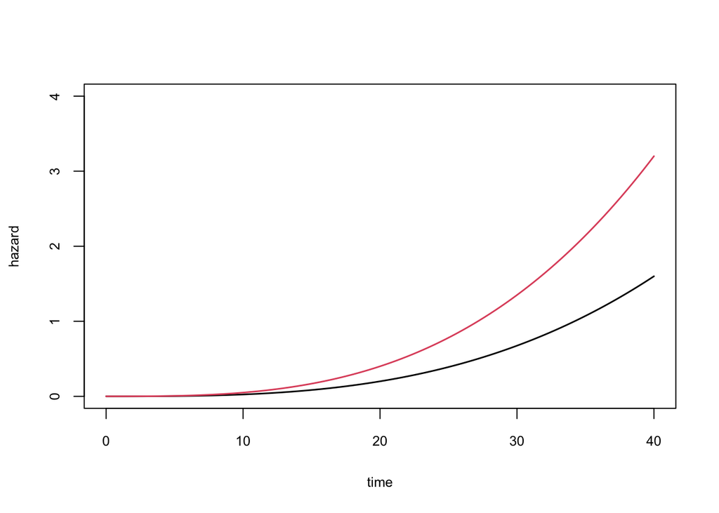

```r
curve(dweibull(x,4,20)/pweibull(x,4,20,lower.tail=F),0,40,ylab="hazard",xlab="time",cex.axis=0.8,cex.lab=0.8,ylim=c(0,4),lwd=1.5)
curve(2*dweibull(x,4,20)/pweibull(x,4,20,lower.tail=F),col=2,add=TRUE,lwd=1.5)
```

In the second example we take a gamma with parameters shape $a=4$ and rate $r=2$ in one group and in the second, we multiply the hazard by 1.5, to give a PH model.

Note: gamma model with shape $a$ and rate $r$ is parameterized as
$$f(t) = \frac{r^a}{\Gamma(a)}t^{a-1}\exp(-r
t ),$$
for $a,r>0$.

The hazard is not available in closed form but is either monotonic increasing in time if $a>1$, monotonic decreasing if $a<1$ and constant if $a=1$.

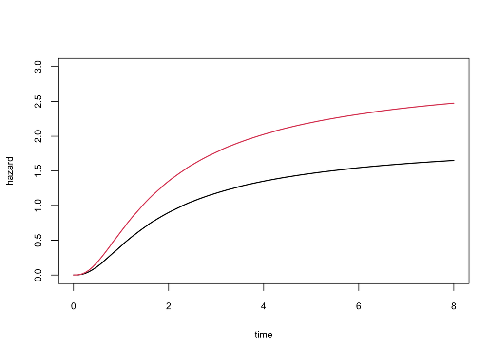

```r
curve(dgamma(x,shape=4,rate=2)/pgamma(x,shape=4,rate=2,lower.tail=F),0,8,ylab="hazard",xlab="time",cex.axis=0.8,cex.lab=0.8,ylim=c(0,3),lwd=1.5)
curve(1.5*dgamma(x,shape=4,rate=2)/pgamma(x,shape=4,rate=2,lower.tail=F),col=2,add=TRUE,lwd=1.5)
```

Now we produce a non-proportional hazards by taking a baseline Weibull and multiplying the hazard by a non-constant function in time.

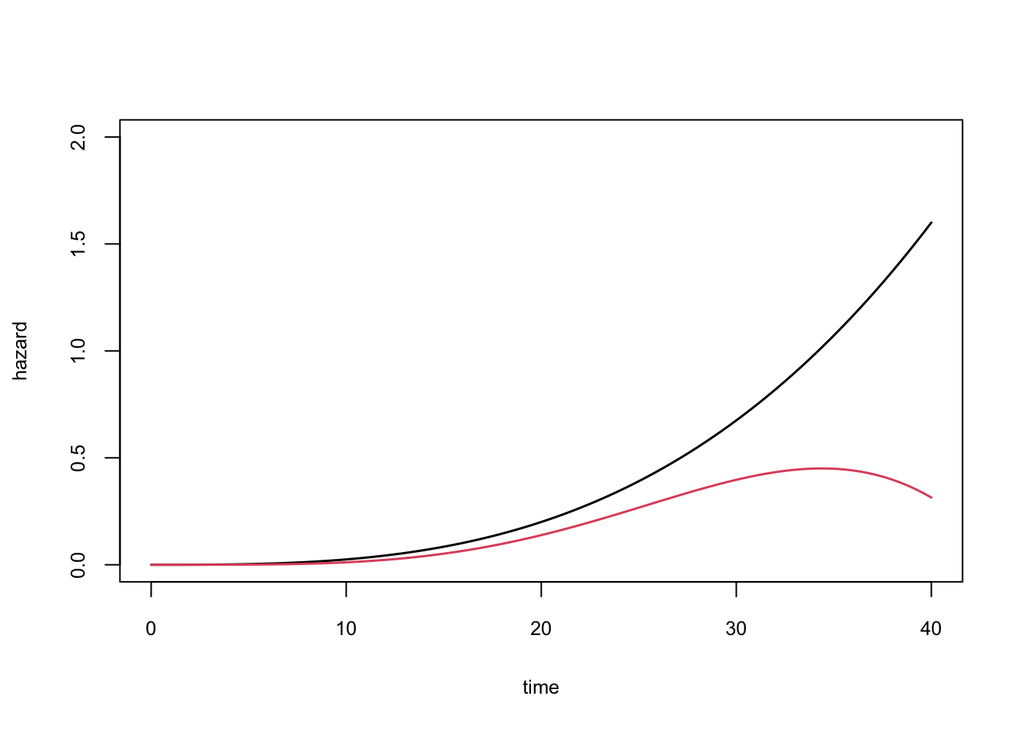

```r
curve(dweibull(x,4,20)/pweibull(x,4,20,lower.tail=F),0,40,ylab="hazard",xlab="time",cex.axis=0.8,cex.lab=0.8,ylim=c(0,2),lwd=1.5)
curve(0.7*sin(x/14)*dweibull(x,4,20)/pweibull(x,4,20,lower.tail=F),col=2,add=TRUE,lwd=1.5)
```

Next, we produce Weibull and gamma survivor functions which cross and therefore cannot be PH.

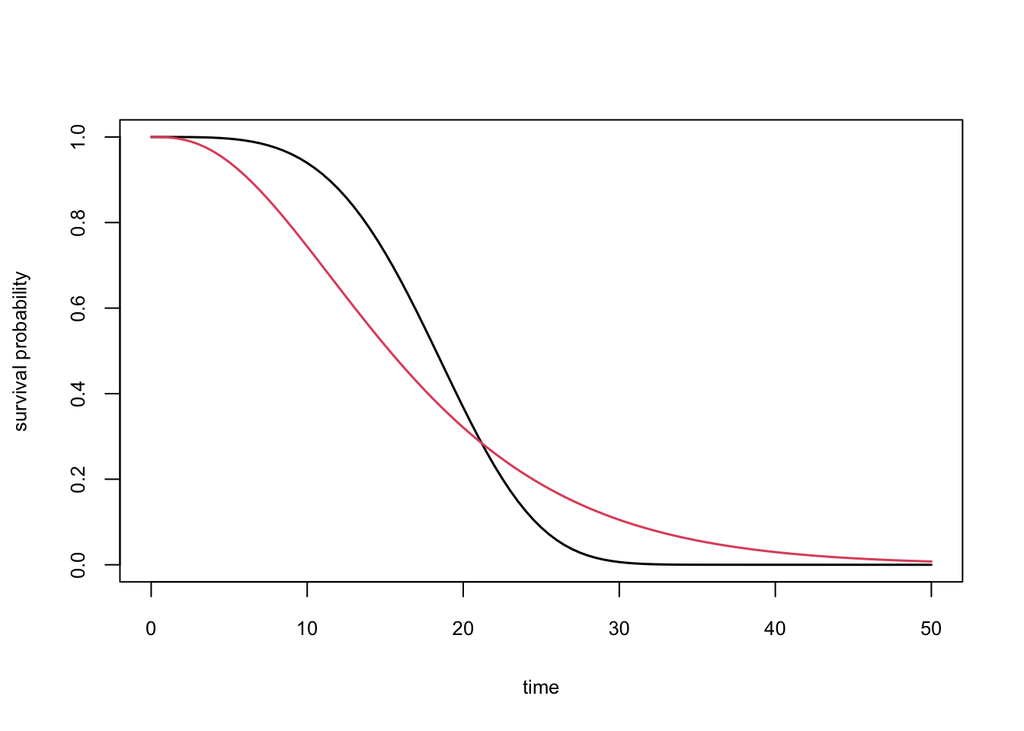

```r
curve(1-pweibull(x,4,20),0,50,ylab="survival probability",xlab="time",cex.axis=0.8,cex.lab=0.8,ylim=c(0,1),lwd=1.5)
curve(1-pgamma(3.5*x,3,1/20),col=2,add=TRUE,lwd=1.5)
```

The final example considers two different gamma functions. First we plot the survivor functions:

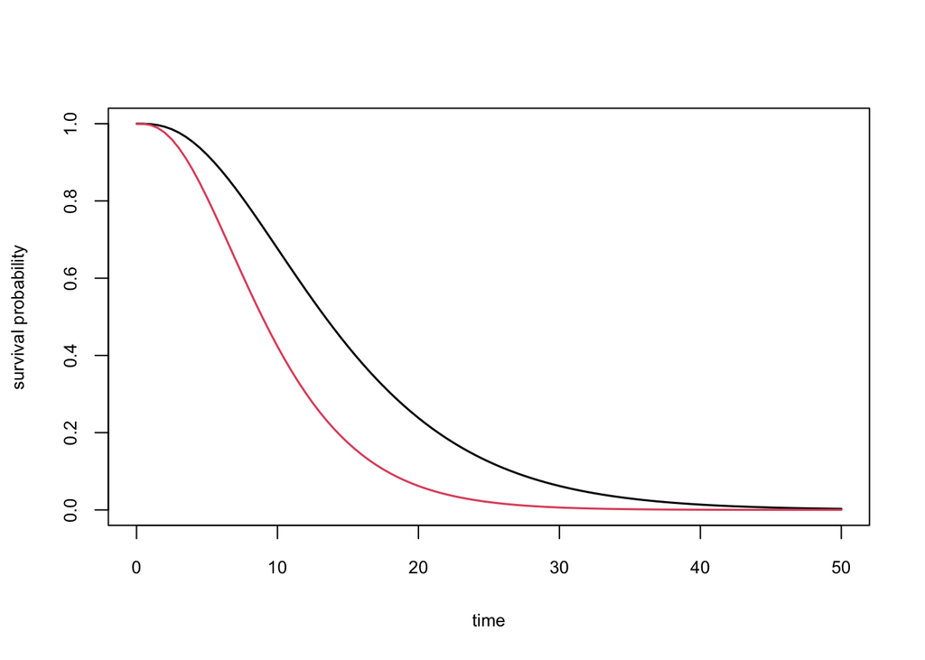

```r
curve(1-pgamma(4*x,3,1/20),0,50,ylab="survival probability",xlab="time",cex.axis=0.8,cex.lab=0.8,ylim=c(0,1),lwd=1.5)
curve(1-pgamma(6*x,3,1/20),col=2,add=TRUE,lwd=1.5)
```

The hazard functions are below, and we do not have PH.

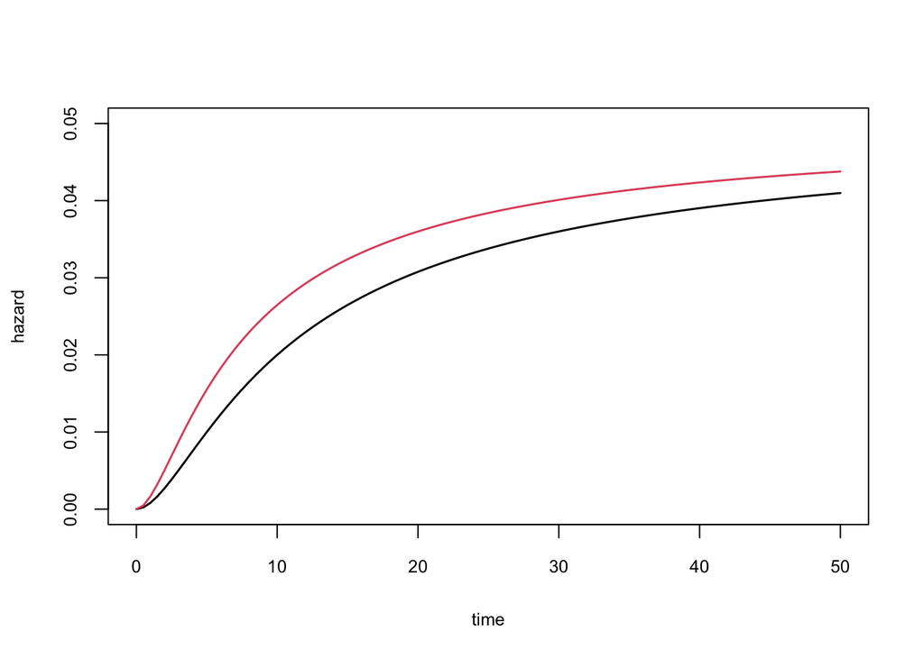

```r
curve(dgamma(4*x,3,1/20)/pgamma(4*x,3,1/20,lower.tail=F),0,50,ylab="hazard",xlab="time",cex.axis=0.8,cex.lab=0.8,ylim=c(0,0.05),lwd=1.5)
curve(dgamma(6*x,3,1/20)/pgamma(6*x,3,1/20,lower.tail=F),col=2,add=TRUE,lwd=1.5)
```

## Examples of Cox PH Modeling with the Herpes Data

Association with Sex

```r
library(foreign)
library(msm)
herpes = read.csv("herpes.csv")
s.herpes = with(herpes, Surv(timetorec, event))
herpes.cox.1 = coxph(s.herpes ~ male, data=herpes)
summary(herpes.cox.1)
```

```
## Call:
## coxph(formula = s.herpes ~ male, data = herpes)
##
##   n= 456, number of events= 372
##
##        coef exp(coef) se(coef)     z Pr(>|z|)
## male 0.1410    1.1515   0.1093 1.291    0.197
##
##      exp(coef) exp(-coef) lower .95 upper .95
## male     1.151     0.8684    0.9295     1.427
##
## Concordance= 0.51  (se = 0.013 )
## Likelihood ratio test= 1.64  on 1 df,   p=0.2
## Wald test            = 1.67  on 1 df,   p=0.2
## Score (logrank) test = 1.67  on 1 df,   p=0.2
```

Association with Type as Quantitative

```r
herpes.cox.2 = coxph(s.herpes ~ type, data=herpes)
summary(herpes.cox.2)
```

```
## Call:
## coxph(formula = s.herpes ~ type, data = herpes)
##
##   n= 456, number of events= 372
##
##         coef exp(coef) se(coef)     z Pr(>|z|)
## type 0.70757   2.02906  0.09318 7.594  3.1e-14 ***
## ---
## Signif. codes:  0 '***' 0.001 '**' 0.01 '*' 0.05 '.' 0.1 ' ' 1
##
##      exp(coef) exp(-coef) lower .95 upper .95
## type     2.029     0.4928      1.69     2.436
##
## Concordance= 0.599  (se = 0.013 )
## Likelihood ratio test= 57.37  on 1 df,   p=4e-14
## Wald test            = 57.67  on 1 df,   p=3e-14
## Score (logrank) test = 57.54  on 1 df,   p=3e-14
```

Type as a Factor

```r
herpes$type. = as.factor(herpes$type)
herpes.cox.3 = coxph(s.herpes ~ type., data=herpes)
summary(herpes.cox.3)
```

```
## Call:
## coxph(formula = s.herpes ~ type., data = herpes)
##
##   n= 456, number of events= 372
##
##          coef exp(coef) se(coef)     z Pr(>|z|)
## type.2 1.1511    3.1618   0.1786 6.446 1.15e-10 ***
## type.3 1.5238    4.5896   0.2168 7.029 2.08e-12 ***
## ---
## Signif. codes:  0 '***' 0.001 '**' 0.01 '*' 0.05 '.' 0.1 ' ' 1
##
##        exp(coef) exp(-coef) lower .95 upper .95
## type.2     3.162     0.3163     2.228     4.487
## type.3     4.590     0.2179     3.001     7.019
##
## Concordance= 0.599  (se = 0.013 )
## Likelihood ratio test= 68.07  on 2 df,   p=2e-15
## Wald test            = 52.93  on 2 df,   p=3e-12
## Score (logrank) test = 59.09  on 2 df,   p=1e-13
```

Association with Treatment

```r
survdiff(s.herpes ~ treat, data=herpes)
```

```
## Call:
## survdiff(formula = s.herpes ~ treat, data = herpes)
##
##           N Observed Expected (O-E)^2/E (O-E)^2/V
## treat=0 270      221    221.1  0.000036  8.98e-05
## treat=1  40       30     38.3  1.814136  2.05e+00
## treat=2 130      111     96.0  2.355958  3.21e+00
## treat=3  16       10     16.6  2.628591  2.78e+00
##
##  Chisq= 6.9  on 3 degrees of freedom, p= 0.08
```

Treatment as Quantitative

```r
herpes.cox.4 = coxph(s.herpes ~ treat, data=herpes)
summary(herpes.cox.4)
```

```
## Call:
## coxph(formula = s.herpes ~ treat, data = herpes)
##
##   n= 456, number of events= 372
##
##           coef exp(coef) se(coef)     z Pr(>|z|)
## treat 0.005313  1.005327 0.052546 0.101    0.919
##
##       exp(coef) exp(-coef) lower .95 upper .95
## treat     1.005     0.9947    0.9069     1.114
##
## Concordance= 0.504  (se = 0.015 )
## Likelihood ratio test= 0.01  on 1 df,   p=0.9
## Wald test            = 0.01  on 1 df,   p=0.9
## Score (logrank) test = 0.01  on 1 df,   p=0.9
```

Treatment as Four-Level Factor

```r
herpes$treat. = as.factor(herpes$treat)
herpes.cox.5 = coxph(s.herpes ~ treat., data=herpes)
summary(herpes.cox.5)
```

```
## Call:
## coxph(formula = s.herpes ~ treat., data = herpes)
##
##   n= 456, number of events= 372
##
##            coef exp(coef) se(coef)      z Pr(>|z|)
## treat.1 -0.2467    0.7814   0.1947 -1.267    0.205
## treat.2  0.1473    1.1587   0.1164  1.266    0.206
## treat.3 -0.5101    0.6005   0.3234 -1.577    0.115
##
##         exp(coef) exp(-coef) lower .95 upper .95
## treat.1    0.7814      1.280    0.5335     1.145
## treat.2    1.1587      0.863    0.9223     1.456
## treat.3    0.6005      1.665    0.3186     1.132
##
## Concordance= 0.538  (se = 0.015 )
## Likelihood ratio test= 7.37  on 3 df,   p=0.06
## Wald test            = 6.78  on 3 df,   p=0.08
## Score (logrank) test = 6.89  on 3 df,   p=0.08
```

Treatment as Two-Level Factor

```r
herpes$treat.any = as.numeric(herpes$treat>0)
herpes.cox.6 = coxph(s.herpes ~ treat.any, data=herpes)
summary(herpes.cox.6)
```

```
## Call:
## coxph(formula = s.herpes ~ treat.any, data = herpes)
##
##   n= 456, number of events= 372
##
##               coef exp(coef) se(coef)    z Pr(>|z|)
## treat.any 0.001049  1.001049 0.105607 0.01    0.992
##
##           exp(coef) exp(-coef) lower .95 upper .95
## treat.any     1.001      0.999    0.8139     1.231
##
## Concordance= 0.503  (se = 0.014 )
## Likelihood ratio test= 0  on 1 df,   p=1
## Wald test            = 0  on 1 df,   p=1
## Score (logrank) test = 0  on 1 df,   p=1
```

Duration

```r
herpes.cox.7 = coxph(s.herpes ~ duration, data=herpes)
summary(herpes.cox.7)
```

```
## Call:
## coxph(formula = s.herpes ~ duration, data = herpes)
##
##   n= 456, number of events= 372
##
##              coef exp(coef) se(coef)     z Pr(>|z|)
## duration 0.022159  1.022407 0.006706 3.304 0.000952 ***
## ---
## Signif. codes:  0 '***' 0.001 '**' 0.01 '*' 0.05 '.' 0.1 ' ' 1
##
##          exp(coef) exp(-coef) lower .95 upper .95
## duration     1.022     0.9781     1.009     1.036
##
## Concordance= 0.552  (se = 0.016 )
## Likelihood ratio test= 10.37  on 1 df,   p=0.001
## Wald test            = 10.92  on 1 df,   p=0.001
## Score (logrank) test = 10.92  on 1 df,   p=9e-04
```

Joint Analysis

```r
herpes.cox.joint = coxph(s.herpes ~ male + type. + treat. + duration,
     data=herpes)
summary(herpes.cox.joint)$coef
```

```
##                 coef exp(coef)    se(coef)          z     Pr(>|z|)
## male      0.22852298 1.2567424 0.111383094  2.0516846 4.020033e-02
## type.2    1.23614875 3.4423306 0.182607471  6.7694314 1.292895e-11
## type.3    1.57593310 4.8352513 0.218351309  7.2174200 5.298314e-13
## treat.1  -0.03503918 0.9655676 0.196958056 -0.1779017 8.588002e-01
## treat.2   0.38977598 1.4766500 0.124006792  3.1431825 1.671216e-03
## treat.3  -0.26651358 0.7660456 0.326019709 -0.8174769 4.136559e-01
## duration  0.02593113 1.0262703 0.006896099  3.7602614 1.697359e-04
```

Joint Analysis

```r
herpes.cox.joint.int = coxph(s.herpes ~ male + type.*treat. + duration,
    data=herpes)
summary(herpes.cox.joint.int)$coef
```

```
##                       coef exp(coef)    se(coef)           z     Pr(>|z|)
## male            0.21523104 1.2401484 0.112424796  1.91444460 5.556337e-02
## type.2          1.24559382 3.4749977 0.279560605  4.45554130 8.368178e-06
## type.3          1.65306887 5.2229839 0.327189703  5.05232547 4.364631e-07
## treat.1         0.01006587 1.0101167 0.567348976  0.01774194 9.858447e-01
## treat.2         0.42197861 1.5249759 0.361077178  1.16866596 2.425382e-01
## treat.3        -0.39411156 0.6742788 1.035814767 -0.38048459 7.035857e-01
## duration        0.02491140 1.0252243 0.006991283  3.56320910 3.663486e-04
## type.2:treat.1 -0.12572931 0.8818535 0.614326604 -0.20466200 8.378362e-01
## type.3:treat.1  0.21353392 1.2380455 0.723646506  0.29508043 7.679324e-01
## type.2:treat.2  0.01323508 1.0133231 0.388561993  0.03406171 9.728279e-01
## type.3:treat.2 -0.25265523 0.7767356 0.470192615 -0.53734411 5.910299e-01
## type.2:treat.3  0.14592257 1.1571066 1.090844360  0.13377029 8.935842e-01
## type.3:treat.3          NA        NA 0.000000000          NA           NA
```

Why is there no hazard ratio estimate for the type=3/treat=3 subgroup?

```r
table(herpes$treat, herpes$type, dnn = c("treat", "type"))
```

```
##      type
## treat   1   2   3
##     0  32 206  32
##     1   9  25   6
##     2  26  83  21
##     3   3  13   0
```

How do more complex models compare to simpler ones?

```r
anova(herpes.cox.joint.int, herpes.cox.joint)
## Analysis of Deviance Table
##  Cox model: response is  s.herpes
##  Model 1: ~ male + type. * treat. + duration
##  Model 2: ~ male + type. + treat. + duration
##    loglik  Chisq Df Pr(>|Chi|)
## 1 -1969.1
## 2 -1969.9 1.4623  5     0.9174
```

Conclude that interactions not required.

```r
anova(herpes.cox.joint, herpes.cox.5)
## Analysis of Deviance Table
##  Cox model: response is  s.herpes
##  Model 1: ~ male + type. + treat. + duration
##  Model 2: ~ treat.
##    loglik  Chisq Df Pr(>|Chi|)
## 1 -1969.9
## 2 -2013.0 86.271  4  < 2.2e-16 ***
## ---
## Signif. codes:  0 '***' 0.001 '**' 0.01 '*' 0.05 '.' 0.1 ' ' 1
```

Conclude that treatment only model too simple.

## Examples of Cox PH Modeling with the Trace Data

```r
trace = read.dta("traceST11.dta")
head(trace)
```

```
##     no wmi status chf    age sex diabetes     time vf
## 1 1944 1.5      9   0 84.924   1        1 1.345000  0
## 2 5783 1.9      0   1 74.193   0        0 6.910000  0
## 3  784 0.8      9   0 78.081   0        1 0.196000  0
## 4 3763 1.3      0   0 55.479   1        0 7.543000  0
## 5 2927 1.6      0   1 62.997   0        0 7.126000  0
## 6 4511 1.0      9   1 67.644   1        0 4.532606  0
```

```r
s.trace = with(trace, Surv(time, (status==9)))
trace.cox.1 = coxph(s.trace ~ wmi, data=trace)
summary(trace.cox.1)
```

```
## Call:
## coxph(formula = s.trace ~ wmi, data = trace)
##
##   n= 500, number of events= 259
##
##        coef exp(coef) se(coef)      z Pr(>|z|)
## wmi -1.2585    0.2841   0.1573 -7.999 1.26e-15 ***
## ---
## Signif. codes:  0 '***' 0.001 '**' 0.01 '*' 0.05 '.' 0.1 ' ' 1
##
##     exp(coef) exp(-coef) lower .95 upper .95
## wmi    0.2841       3.52    0.2087    0.3867
##
## Concordance= 0.645  (se = 0.017 )
## Likelihood ratio test= 63.26  on 1 df,   p=2e-15
## Wald test            = 63.98  on 1 df,   p=1e-15
## Score (logrank) test = 66.08  on 1 df,   p=4e-16
```